# Blogs, news, and tweets: an exploratory analysis

Gunther

2023-10-26

## Exploratory Analysis of the English data from the U.S.

There are three sets of data: blogs, news, and tweets. Lets look at these three separately and get a sense of the word distribution on each set of data.

### Load all the data.

```r
blogs <- readLines("Coursera-SwiftKey/final/en_US/en_US.blogs.txt")

news <- readLines("Coursera-SwiftKey/final/en_US/en_US.news.txt")

twitter <- readLines("Coursera-SwiftKey/final/en_US/en_US.twitter.txt")
```

### How many lines, words, and charcters of the text are there in the blog data.

```r
blog_num_lines <- length(blogs)
print(paste("The number of lines of text in the blog data is",blog_num_lines))
```

```
## [1] "The number of lines of text in the blog data is 899288"
```

```r
blog_combined <- paste(blogs,collapse = " ")
blog_words <- unlist(strsplit(blog_combined , "\\s+"))
blog_words_num <- length(blog_words)
print(paste("The number of words in all the blog posts are",blog_words_num))
```

```
## [1] "The number of words in all the blog posts are 37334131"
```

```r
blogs_char_lengths <- sapply(blogs, nchar)
blog_char_num <- sum(blogs_char_lengths)
print(paste("The number of characters in all the blog posts are", blog_char_num))
```

```
## [1] "The number of characters in all the blog posts are 206824509"
```

### The average words per line in the blogs. I’ll only look at the first 10,000 entries since it will take a long time to process the whole set.

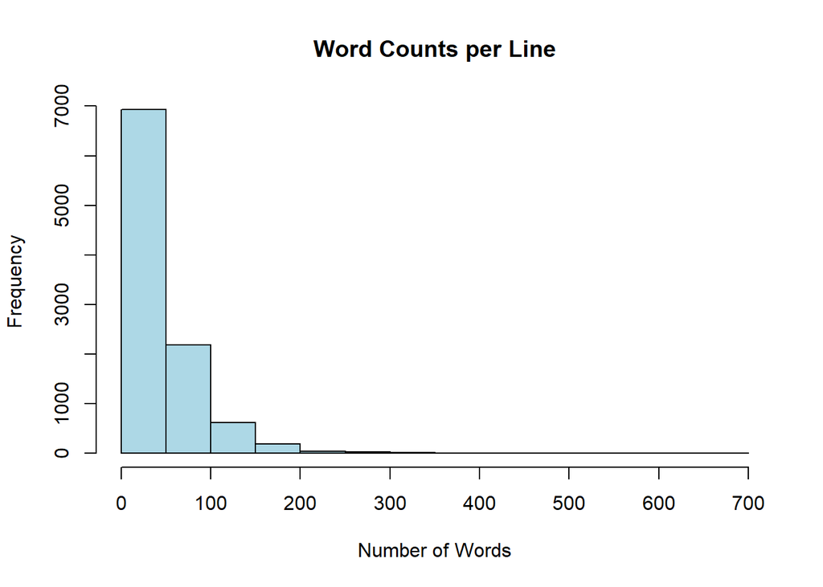

```r
# Initialize an empty vector to store word counts
word_counts <- c()

# Loop through each line and count words
for (line in blogs[1:10000]) {
  words <- unlist(strsplit(line, "\\s+"))  # Split the line into words
  word_count <- length(words)  # Count the number of words
  word_counts <- c(word_counts, word_count)  # Append word count to the vector
}

# Create a histogram
hist(word_counts,
     main = "Word Counts per Line",
     xlab = "Number of Words",
     ylab = "Frequency",
     col = "lightblue")
```

```r
print(paste("The average number of words in a post is",mean(word_count)))
```

[output not shown]

### Let’s see what are the most common words used, excluding stop words. I’ll only look at the first 10,000 entries since it will take a long time to process the whole set.

```r
library(tm)
library(stringr)
```

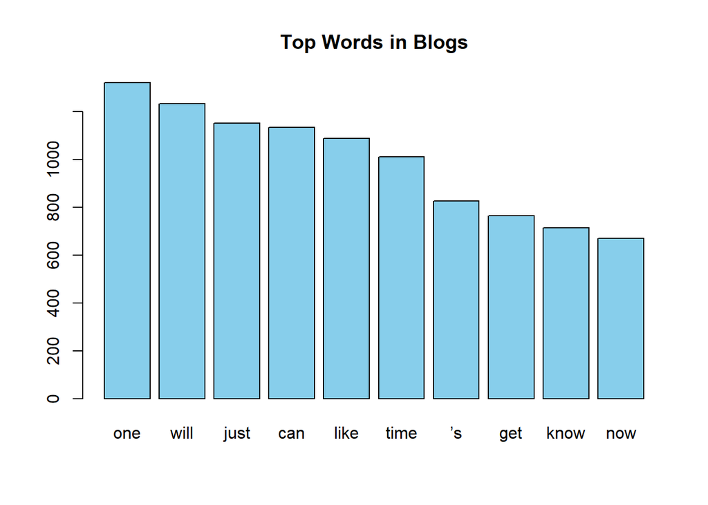

```r
corpus <- Corpus(VectorSource(blogs[1:10000]))
corpus <- tm_map(corpus, content_transformer(tolower))
corpus <- tm_map(corpus, removePunctuation)
# corpus <- tm_map(corpus, removeNumbers)
corpus <- tm_map(corpus, removeWords, stopwords("english"))
corpus <- tm_map(corpus, stripWhitespace)

dtm <- DocumentTermMatrix(corpus)
# Convert the DTM into a matrix
mat <- as.matrix(dtm)

# Calculate word frequencies
word_freqs <- colSums(mat)
# Sort word frequencies in descending order
sorted_word_freqs <- sort(word_freqs, decreasing = TRUE)
top_n <- 10  # Change this to the number of top words you want to display
top_words <- names(sorted_word_freqs[1:top_n])
top_word_freqs <- sorted_word_freqs[1:top_n]
# Create a bar graph
barplot(top_word_freqs, names.arg = top_words, col = "skyblue", main = "Top Words in Blogs")
```

# News

```r
news_num_lines <- length(news)
print(paste("The number of lines of text in the news data is",news_num_lines))
```

```
## [1] "The number of lines of text in the news data is 77259"
```

```r
news_combined <- paste(news,collapse = " ")
news_words <- unlist(strsplit(news_combined , "\\s+"))
news_words_num <- length(news_words)
print(paste("The number of words in all the news posts are",news_words_num))
```

```
## [1] "The number of words in all the news posts are 2643969"
```

```r
news_char_lengths <- sapply(news, nchar)
news_char_num <- sum(news_char_lengths)
print(paste("The number of characters in all the news posts are", news_char_num))
```

```
## [1] "The number of characters in all the news posts are 15639408"
```

### The average words per line in the news.

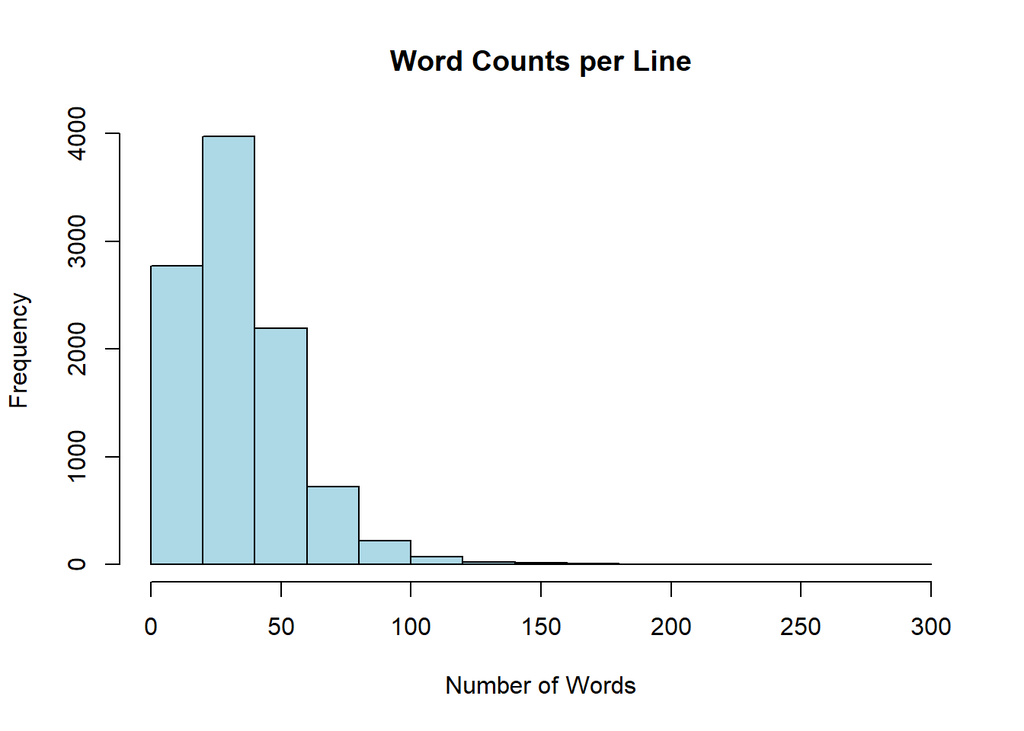

```r
# Initialize an empty vector to store word counts
word_counts <- c()

# Loop through each line and count words
for (line in news[1:10000]) {
  words <- unlist(strsplit(line, "\\s+"))  # Split the line into words
  word_count <- length(words)  # Count the number of words
  word_counts <- c(word_counts, word_count)  # Append word count to the vector
}

# Create a histogram
hist(word_counts,
     main = "Word Counts per Line",
     xlab = "Number of Words",
     ylab = "Frequency",
     col = "lightblue")
```

```r
print(paste("The average number of words in a post is",mean(word_count)))
```

[output not shown]

## Let’s see what are the most common words used, excluding stop words. I’ll only look at the first 10,000 entries since it will take a long time to process the whole set.

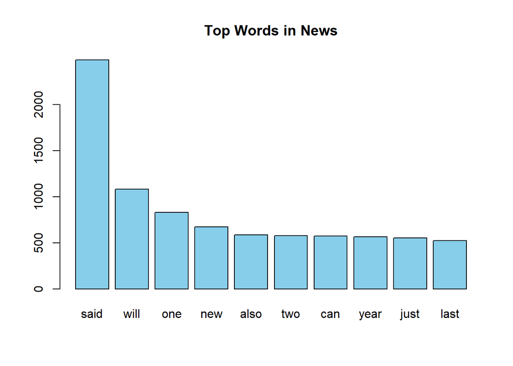

```r
corpus <- Corpus(VectorSource(news[1:10000]))
corpus <- tm_map(corpus, content_transformer(tolower))
corpus <- tm_map(corpus, removePunctuation)
# corpus <- tm_map(corpus, removeNumbers)
corpus <- tm_map(corpus, removeWords, stopwords("english"))
corpus <- tm_map(corpus, stripWhitespace)

dtm <- DocumentTermMatrix(corpus)
# Convert the DTM into a matrix
mat <- as.matrix(dtm)

# Calculate word frequencies
word_freqs <- colSums(mat)
# Sort word frequencies in descending order
sorted_word_freqs <- sort(word_freqs, decreasing = TRUE)
top_n <- 10  # Change this to the number of top words you want to display
top_words <- names(sorted_word_freqs[1:top_n])
top_word_freqs <- sorted_word_freqs[1:top_n]
# Create a bar graph
barplot(top_word_freqs, names.arg = top_words, col = "skyblue", main = "Top Words in News")
```

# Twitter

```r
tweet_num_lines <- length(twitter)
print(paste("The number of lines of text in the news data is",tweet_num_lines))
```

[output not shown]

```r
tweet_combined <- paste(twitter,collapse = " ")
tweet_words <- unlist(strsplit(tweet_combined , "\\s+"))
tweet_words_num <- length(tweet_words)
print(paste("The number of words in all the news posts are",tweet_words_num))
```

[output not shown]

```r
tweet_char_lengths <- sapply(twitter, nchar)
tweet_char_num <- sum(tweet_char_lengths)
print(paste("The number of characters in all the news posts are", tweet_char_num))
```

[output not shown]

### The average words per line in the twitter data set. Using the first 10,000.

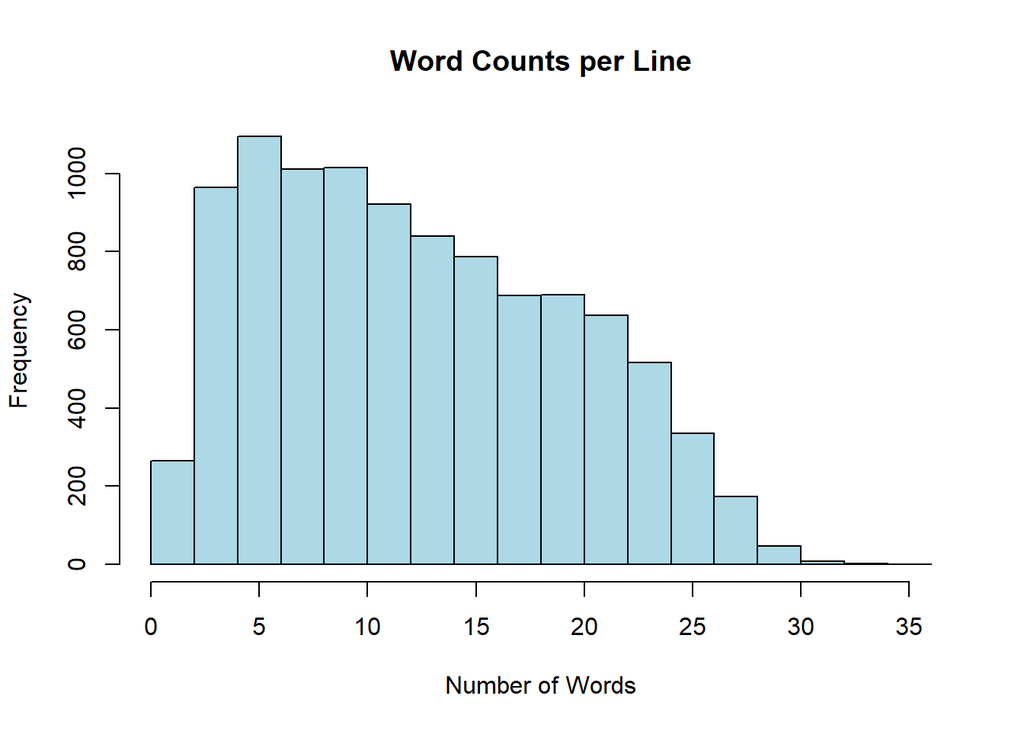

```r
# Initialize an empty vector to store word counts
word_counts <- c()

# Loop through each line and count words
for (line in twitter[1:10000]) {
  words <- unlist(strsplit(line, "\\s+"))  # Split the line into words
  word_count <- length(words)  # Count the number of words
  word_counts <- c(word_counts, word_count)  # Append word count to the vector
}

# Create a histogram
hist(word_counts,
     main = "Word Counts per Line",
     xlab = "Number of Words",
     ylab = "Frequency",
     col = "lightblue")
```

```r
print(paste("The average number of words in a post is",mean(word_count)))
```

[output not shown]

### Let’s see what are the most common words used, excluding stop words. I’ll only look at the first 10,000 entries since it will take a long time to process the whole set.

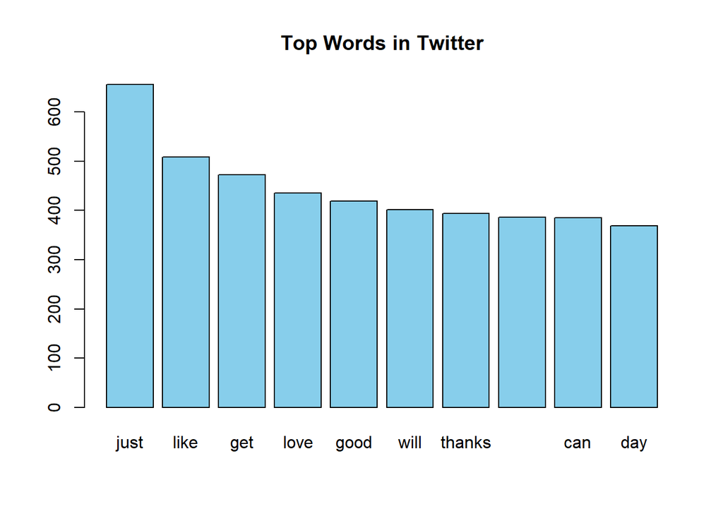

```r
library(tm)
library(stringr)

corpus <- Corpus(VectorSource(twitter[1:10000]))
corpus <- tm_map(corpus, content_transformer(tolower))
corpus <- tm_map(corpus, removePunctuation)
# corpus <- tm_map(corpus, removeNumbers)
corpus <- tm_map(corpus, removeWords, stopwords("english"))
corpus <- tm_map(corpus, stripWhitespace)

dtm <- DocumentTermMatrix(corpus)
# Convert the DTM into a matrix
mat <- as.matrix(dtm)

# Calculate word frequencies
word_freqs <- colSums(mat)
# Sort word frequencies in descending order
sorted_word_freqs <- sort(word_freqs, decreasing = TRUE)
top_n <- 10  # Change this to the number of top words you want to display
top_words <- names(sorted_word_freqs[1:top_n])
top_word_freqs <- sorted_word_freqs[1:top_n]
# Create a bar graph
barplot(top_word_freqs, names.arg = top_words, col = "skyblue", main = "Top Words in Twitter")
```